# Reproducible Research: Peer Assessment 1

Silverio Neves

24 September 2018

## Loading and preprocessing the data

Load data from “activity.csv” in “activity” data.frame

```r
if(!require(readr)) install.packages("readr")
library(readr)
activity <- read_csv("activity.csv")
d <- dim(activity)
```

Data.frame with 17568 observations and 3 variables (“steps”, “date”,“interval”)

## What is mean total number of steps taken per day?

```r
if(!require(dplyr)) install.packages("dplyr")
library(dplyr)
activityday <- group_by(activity, date)
sumstepsday <- dplyr::summarise(activityday, stepsday = sum(steps, na.rm = TRUE))
m <- as.integer(mean(sumstepsday$stepsday, na.rm = TRUE))
t <- as.integer(sum(sumstepsday$stepsday, na.rm = TRUE))
med <- as.integer(median(sumstepsday$stepsday, na.rm = TRUE))
```

In the figure we can see the histogram of the total number of steps taken each day

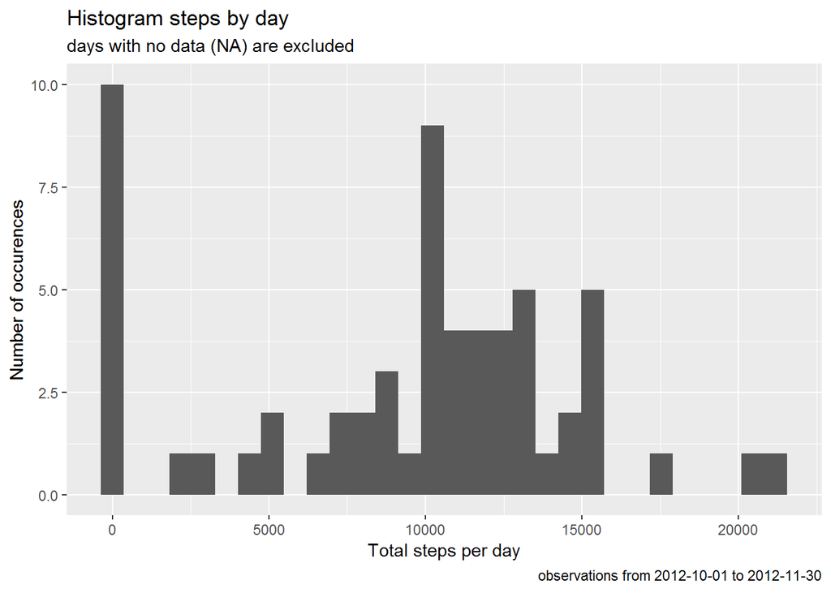

```r
if(!require(ggplot2)) install.packages("ggplot2")
library(ggplot2)
qplot(sumstepsday$stepsday, geom="histogram")+
        labs(title = "Histogram steps by day", subtitle = "days with no data (NA) are excluded",
                y = "Number of occurences", caption = "observations from 2012-10-01 to 2012-11-30",
                x = "Total steps per day")
```

We can see in the plot bellow the behaviour (steps by day). A time series plot of the average number of steps taken.

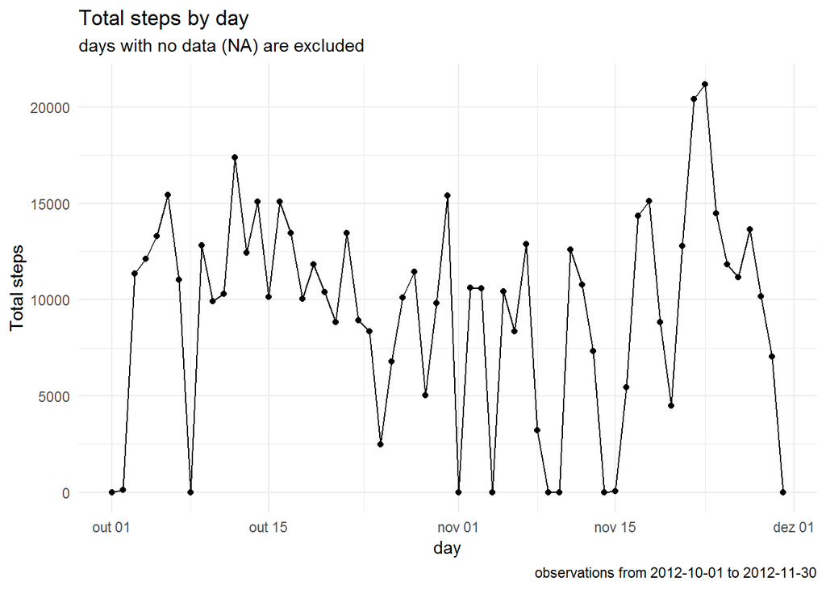

```r
if(!require(ggplot2)) install.packages("ggplot2")
library(ggplot2)
ggplot(data=sumstepsday,
        aes(x=date, y=stepsday)) +
        geom_line() +
        geom_point() +
        scale_color_brewer(palette="Paired")+
        theme_minimal()+
        theme(legend.position="right")+
        labs(title = "Total steps by day", subtitle = "days with no data (NA) are excluded",
                x = "day", caption = "observations from 2012-10-01 to 2012-11-30",
                y = "Total steps")
```

## What is the average daily activity pattern?

```r
if(!require(dplyr)) install.packages("dplyr")
library(dplyr)
activityinterval <- group_by(activity, interval)
sumstepsinterval <- dplyr::summarise(activityinterval, stepsinterval = mean(steps, na.rm = TRUE))
maxiinterval <- order(sumstepsinterval$stepsinterval, decreasing = TRUE)
```

The **interval** with the **maximum steps in average** is **835** with an **average** of **206**.

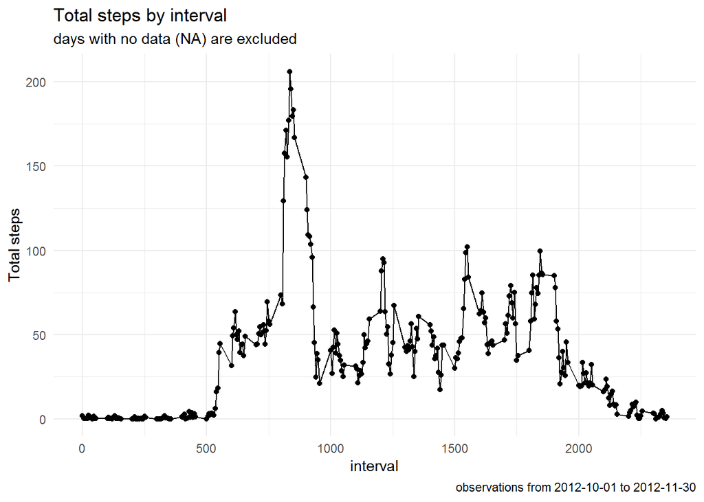

```r
if(!require(ggplot2)) install.packages("ggplot2")
library(ggplot2)
ggplot(data=sumstepsinterval,
        aes(x=interval, y=stepsinterval)) +
        geom_line() +
        geom_point() +
        scale_color_brewer(palette="Paired")+
        theme_minimal()+
        theme(legend.position="right")+
        labs(title = "Total steps by interval", subtitle = "days with no data (NA) are excluded",
                x = "interval", caption = "observations from 2012-10-01 to 2012-11-30",
                y = "Total steps")
```

## Imputing missing values

```r
totalrows <- dim(activity)[1]
c <- sum(complete.cases(activity))
s <- sum(is.na(activity$steps))
```

We will **fill NAs values** with the **mean** for the specific **interval** creating a new data.frame “newactivity”

```r
newactivity <- activity
ridna <- which(is.na(newactivity$steps))
for(i in ridna){
        newactivity$steps[i] <- sumstepsinterval$stepsinterval[newactivity$interval[i] == sumstepsinterval$interval]
}
```

```r
if(!require(dplyr)) install.packages("dplyr")
library(dplyr)
newactivityday <- group_by(newactivity, date)
newsumstepsday <- dplyr::summarise(newactivityday, stepsday = sum(steps, na.rm = TRUE))
newm <- as.integer(mean(newsumstepsday$stepsday, na.rm = TRUE))
newt <- as.integer(sum(newsumstepsday$stepsday, na.rm = TRUE))
newmed <- as.integer(median(newsumstepsday$stepsday, na.rm = TRUE))
```

In **average** they do **10766** steps per day, with a **median** of **10766** for a **total** of **656737** steps, excluding days without steps observation (= NA)

All values grew. Mean from 9354 to 10766, and the median from 10395 to 10766. For curiosity, the new mean is equal to the new median.

In the figure we can see the new histogram of the total number of steps taken each day

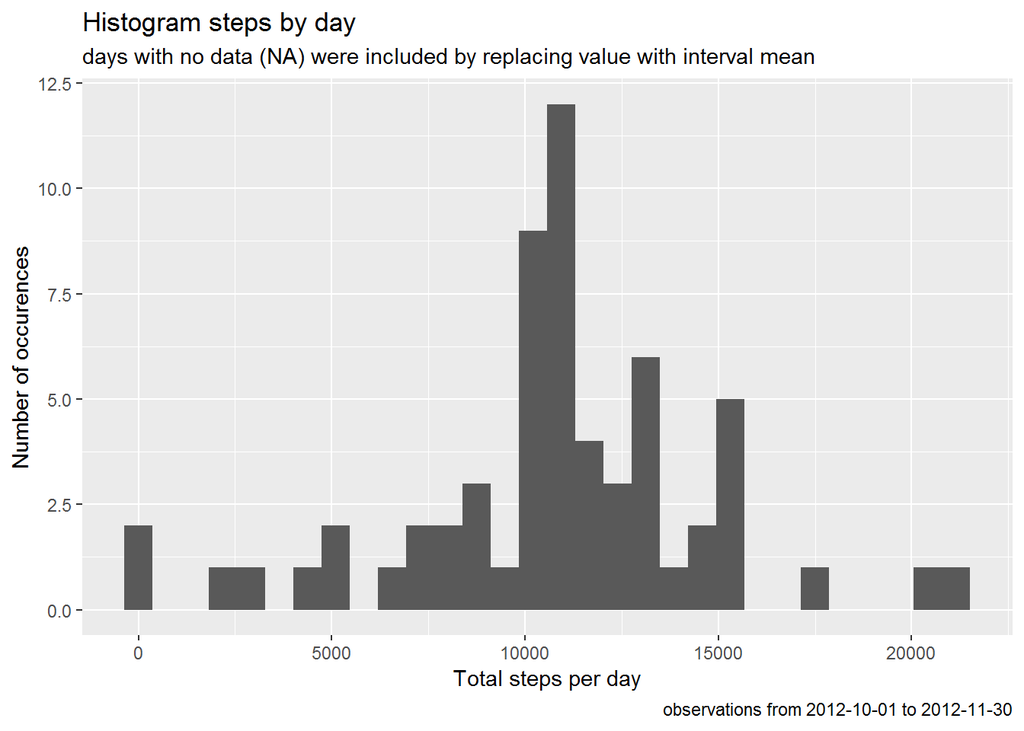

```r
if(!require(ggplot2)) install.packages("ggplot2")
library(ggplot2)
qplot(newsumstepsday$stepsday, geom="histogram")+
        labs(title = "Histogram steps by day", subtitle = "days with no data (NA) were included by replacing value with interval mean",
                y = "Number of occurences", caption = "observations from 2012-10-01 to 2012-11-30",
                x = "Total steps per day")
```

We can see in the plot bellow the behaviour (steps by day)

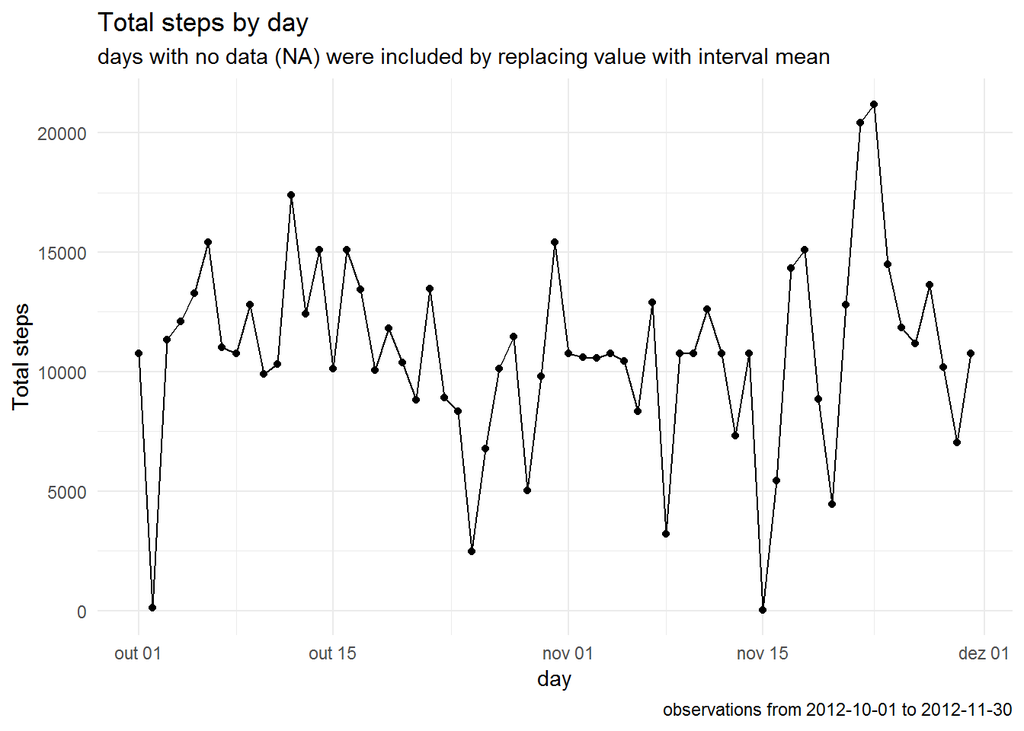

```r
if(!require(ggplot2)) install.packages("ggplot2")
library(ggplot2)
ggplot(data=newsumstepsday,
        aes(x=date, y=stepsday)) +
        geom_line() +
        geom_point() +
        scale_color_brewer(palette="Paired")+
        theme_minimal()+
        theme(legend.position="right")+
        labs(title = "Total steps by day", subtitle = "days with no data (NA) were included by replacing value with interval mean",
                x = "day", caption = "observations from 2012-10-01 to 2012-11-30",
                y = "Total steps")
```

## Are there differences in activity patterns between weekdays and weekends?

First it is necessary to create a new collumn to distinguish from weekday and weekend day. New column has the name “day”

```r
if(!require(dplyr)) install.packages("dplyr")
library(dplyr)

days <- c("sábado", "domingo") ## need to change for local and system language day names
newactivity$day <- 0
for (i in 1:dim(newactivity)[1])
{
        if (weekdays(newactivity$date[i]) %in% days) {newactivity$day[i] = "weekend"} else {newactivity$day[i] = "weekday"}
}
```

Now we will generate a graphic to compare weekday and weekend days performance

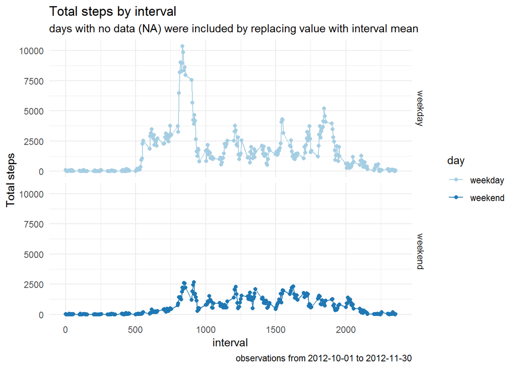

```r
if(!require(dplyr)) install.packages("dplyr")
library(dplyr)
newactivityweek <- group_by(newactivity, interval, day)
newsumstepsweek <- dplyr::summarise(newactivityweek, stepsinterval = sum(steps, na.rm = TRUE))

if(!require(ggplot2)) install.packages("ggplot2")
library(ggplot2)
ggplot(data=newsumstepsweek,
        aes(x=interval, y=stepsinterval, col = day)) +
        geom_line() +
        geom_point() +
        facet_grid(day~.) +
        scale_color_brewer(palette="Paired")+
        theme_minimal()+
        theme(legend.position="right")+
        labs(title = "Total steps by interval", subtitle = "days with no data (NA) were included by replacing value with interval mean",
                x = "interval", caption = "observations from 2012-10-01 to 2012-11-30",
                y = "Total steps")
```